# PART 1 QUESTION BASED

# Final conclusion is funds raised by companies that are still operating and companies that closed down are not equal

# Make a copy of the original data frame

```python
df_original = pd.read_csv('DS - Part3 - CompanyX_EU.csv')
df_original.head()                                                    #original Dataframe
```

|  | Startup | Product | Funding | Event | Result | OperatingState |
| --- | --- | --- | --- | --- | --- | --- |
| 0 | 2600Hz | 2600hz.com | NaN | Disrupt SF 2013 | Contestant | Operating |
| 1 | 3DLT | 3dlt.com | $630K | Disrupt NYC 2013 | Contestant | Closed |
| 2 | 3DPrinterOS | 3dprinteros.com | NaN | Disrupt SF 2016 | Contestant | Operating |
| 3 | 3Dprintler | 3dprintler.com | $1M | Disrupt NY 2016 | Audience choice | Operating |
| 4 | 42 Technologies | 42technologies.com | NaN | Disrupt NYC 2013 | Contestant | Operating |

```python
df1 = df_original.copy()
df1                                                        # copy of the original dataframe
```

|  | Startup | Product | Funding | Event | Result | OperatingState |
| --- | --- | --- | --- | --- | --- | --- |
| 0 | 2600Hz | 2600hz.com | NaN | Disrupt SF 2013 | Contestant | Operating |
| 1 | 3DLT | 3dlt.com | $630K | Disrupt NYC 2013 | Contestant | Closed |
| 2 | 3DPrinterOS | 3dprinteros.com | NaN | Disrupt SF 2016 | Contestant | Operating |
| 3 | 3Dprintler | 3dprintler.com | $1M | Disrupt NY 2016 | Audience choice | Operating |
| 4 | 42 Technologies | 42technologies.com | NaN | Disrupt NYC 2013 | Contestant | Operating |
| ... | ... | ... | ... | ... | ... | ... |
| 657 | Zivity | zivity.com | $8M | TC40 2007 | Contestant | Operating |
| 658 | Zmorph | zmorph3d.com | $1M | - | Audience choice | Operating |
| 659 | Zocdoc | zocdoc.com | $223M | TC40 2007 | Contestant | Operating |
| 660 | Zula | zulaapp.com | $3.4M | Disrupt SF 2013 | Audience choice | Operating |
| 661 | Zumper | zumper.com | $31.5M | Disrupt SF 2012 | Finalist | Operating |

662 rows × 6 columns

# Check frequency distribution of Result variable

```python
df1['Result'].value_counts()      #checking value counts of the 'Result' column
```

```
Contestant         488
Finalist            84
Audience choice     41
Winner              26
Runner up           23
Name: Result, dtype: int64
```

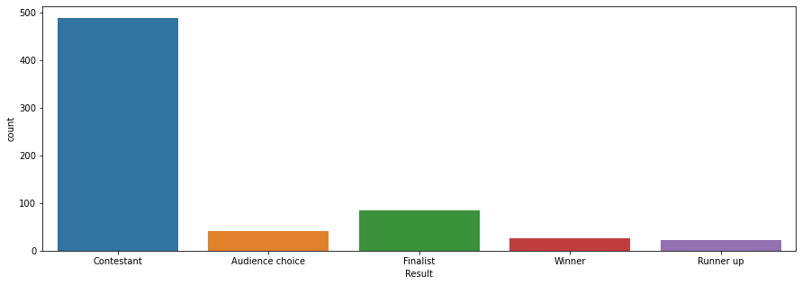

```python
fig = plt.figure(figsize = (15,5))
sns.countplot(x="Result", data=df1);   # plotting value counts of the 'Result' column
```

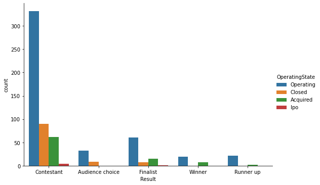

```python
sns.catplot(x="Result", hue='OperatingState',
                data=df1, kind="count",height=5, aspect=1.5);      # plotting value counts of the 'Result' column with respect to its 'Operating State
```

# Calculate percentage of winners that are still operating and percentage of contestants that are still operating

```python
df1_operating = df1[df1['OperatingState'].isin(['Operating'])]    #considering only companies which are operating
df1_operating.head()
```

|  | Startup | Product | Funding | Event | Result | OperatingState |
| --- | --- | --- | --- | --- | --- | --- |
| 0 | 2600Hz | 2600hz.com | NaN | Disrupt SF 2013 | Contestant | Operating |
| 2 | 3DPrinterOS | 3dprinteros.com | NaN | Disrupt SF 2016 | Contestant | Operating |
| 3 | 3Dprintler | 3dprintler.com | $1M | Disrupt NY 2016 | Audience choice | Operating |
| 4 | 42 Technologies | 42technologies.com | NaN | Disrupt NYC 2013 | Contestant | Operating |
| 6 | 8 Securities | 8securities.com | $29M | Disrupt Beijing 2011 | Finalist | Operating |

```python
df1_result =df1_operating[['Startup','Result','OperatingState']]
df1_result.head()                                                             #considering only 3 columns
```

|  | Startup | Result | OperatingState |
| --- | --- | --- | --- |
| 0 | 2600Hz | Contestant | Operating |
| 2 | 3DPrinterOS | Contestant | Operating |
| 3 | 3Dprintler | Audience choice | Operating |
| 4 | 42 Technologies | Contestant | Operating |
| 6 | 8 Securities | Finalist | Operating |

```python
# percentage of winners that are still operating
df1_result_winners = (df1_result['Result'].isin(['Winner']).sum()/len(df1_result))*100
print(f'''percentage of winners that are still operating is {round(df1_result_winners,3)} %''')
```

```
percentage of winners that are still operating is 4.086 %
```

```python
# percentage of Contestants that are still operating
df1_result_contestant = (df1_result['Result'].isin(['Contestant']).sum()/len(df1_result))*100
print(f'''percentage of Contestants that are still operating is {round(df1_result_contestant,3)} %''')
```

```
percentage of Contestants that are still operating is 71.398 %
```

# Write your hypothesis comparing the proportion of companies that are operating between winners and contestants

Write the null hypothesis and alternative hypothesis. Test for significance and conclusion

Step 1: Define null and alternative hypotheses. Null hypothesis: H0 : proportion of companies that are operating between winners and contestants are equal i.e. H0: p1 = p2 Alternate hypothesis: H1 : proportion of companies that are operating between winners and contestants are not equal i.e. H1: p1 ≠ p2 Step 2: Decide the significance level Choose the 𝛼, the level of significance according to the relative importance of the risks of committing Type I and Type II errors in the problem. let,𝛼 = 0.05

```python
df1_result.head()
```

|  | Startup | Result | OperatingState |
| --- | --- | --- | --- |
| 0 | 2600Hz | Contestant | Operating |
| 2 | 3DPrinterOS | Contestant | Operating |
| 3 | 3Dprintler | Audience choice | Operating |
| 4 | 42 Technologies | Contestant | Operating |
| 6 | 8 Securities | Finalist | Operating |

```python
winners = df1_result[df1_result['Result']=='Winner'].OperatingState.value_counts()
winners                                                         # total counts of 'winners' among operating companies
```

```
Operating    19
Name: OperatingState, dtype: int64
```

```python
contestant = df1_result[df1_result['Result']=='Contestant'].OperatingState.value_counts()
contestant                                                      # total counts of 'contestant' among operating companies
```

```
Operating    332
Name: OperatingState, dtype: int64
```

```python
companies_operating = len(df1_result)
companies_operating                                           # number of companies operating
```

```
465
```

companies that are operating let n1(companies that are operating) = n2 = n = 465 #since, number of companies operating is same for both winners # and contenstants number of companies that are winner = 19 number of companies that are contenstant = 332

```python
from statsmodels.stats.proportion import proportions_ztest
```

```python
winner,operating = (19,465)
contestant,operating = (332,465)

winner_contenstant = np.array([winner,contestant])
operating = np.array([operating, operating])

stat,pval = proportions_ztest(count=winner_contenstant, nobs=operating,  alternative='two-sided')
print(stat,pval)
if pval < 0.05:
    print(f'With a p-value of {round(pval,4)} the difference is significant. aka |We reject the null|')
else:
    print(f'With a p-value of {round(pval,4)} the difference is not significant. aka |We fail to reject the null|')
```

```
-21.173515526915622 1.6757881290464125e-99
With a p-value of 0.0 the difference is significant. aka |We reject the null|
```

# Final conclusion is proportion of companies that are operating between winners and contestants are not equal

# Check distribution of the Event variable.

```python
df1.head()
```

|  | Startup | Product | Funding | Event | Result | OperatingState |
| --- | --- | --- | --- | --- | --- | --- |
| 0 | 2600Hz | 2600hz.com | NaN | Disrupt SF 2013 | Contestant | Operating |
| 1 | 3DLT | 3dlt.com | $630K | Disrupt NYC 2013 | Contestant | Closed |
| 2 | 3DPrinterOS | 3dprinteros.com | NaN | Disrupt SF 2016 | Contestant | Operating |
| 3 | 3Dprintler | 3dprintler.com | $1M | Disrupt NY 2016 | Audience choice | Operating |
| 4 | 42 Technologies | 42technologies.com | NaN | Disrupt NYC 2013 | Contestant | Operating |

```python
df1['Event'].value_counts()
```

```
TC50 2008                    52
TC50 2009                    50
TC40 2007                    40
Disrupt NYC 2011             32
Disrupt SF 2013              31
Disrupt SF 2011              31
Disrupt NYC 2013             31
Disrupt NYC 2012             30
Disrupt SF 2012              30
Disrupt SF 2014              28
Disrupt NYC 2014             27
Disrupt SF 2015              27
Disrupt SF 2016              26
Disrupt SF 2010              26
Disrupt NY 2015              26
Disrupt NYC 2010             22
Disrupt NY 2016              22
Disrupt Beijing 2011         18
Disrupt EU 2014              15
Disrupt London 2015          15
Hardware Battlefield 2015    15
Disrupt EU 2013              15
Hardware Battlefield 2014    14
-                            13
Disrupt London 2016          13
Hardware Battlefield 2016    13
Name: Event, dtype: int64
```

# Select only the Event that has disrupt keyword from 2013 onwards

```python
options = ['Disrupt NYC 2013', 'Disrupt SF 2013','Disrupt SF 2014','Disrupt SF 2015','Disrupt NYC 2014','Disrupt NY 2015','Disrupt SF 2016','Disrupt NY 2016','Disrupt London 2015','Disrupt EU 2014','Disrupt EU 2013','Disrupt London 2016']
event_disrupt = df1[df1['Event'].isin(options)]
event_disrupt        #Event that has disrupt keyword from 2013 onwards
```

|  | Startup | Product | Funding | Event | Result | OperatingState |
| --- | --- | --- | --- | --- | --- | --- |
| 0 | 2600Hz | 2600hz.com | NaN | Disrupt SF 2013 | Contestant | Operating |
| 1 | 3DLT | 3dlt.com | $630K | Disrupt NYC 2013 | Contestant | Closed |
| 2 | 3DPrinterOS | 3dprinteros.com | NaN | Disrupt SF 2016 | Contestant | Operating |
| 3 | 3Dprintler | 3dprintler.com | $1M | Disrupt NY 2016 | Audience choice | Operating |
| 4 | 42 Technologies | 42technologies.com | NaN | Disrupt NYC 2013 | Contestant | Operating |
| ... | ... | ... | ... | ... | ... | ... |
| 646 | YayPay Inc | yaypay.com | $900K | Disrupt London 2015 | Contestant | Operating |
| 648 | YOOBIC | yoobic.com | NaN | Disrupt London 2015 | Finalist | Operating |
| 653 | ZAP! | zapreklam.com/ | NaN | Disrupt EU 2014 | Audience choice | Operating |
| 656 | Zenefits | zenefits.com | $583.6M | Disrupt NYC 2013 | Finalist | Operating |
| 660 | Zula | zulaapp.com | $3.4M | Disrupt SF 2013 | Audience choice | Operating |

276 rows × 6 columns

```python
# checking whether 'Event'  has disrupt keyword from '2013' onwards
event_disrupt['Event'].value_counts()
```

```
Disrupt NYC 2013       31
Disrupt SF 2013        31
Disrupt SF 2014        28
Disrupt NYC 2014       27
Disrupt SF 2015        27
Disrupt NY 2015        26
Disrupt SF 2016        26
Disrupt NY 2016        22
Disrupt EU 2014        15
Disrupt London 2015    15
Disrupt EU 2013        15
Disrupt London 2016    13
Name: Event, dtype: int64
```